# Projet - Modélisation statistique

Louison Guillot

2026-06-05

# 1 Introduction

Ce document présente le **travail préparatoire** sur le jeu de données ozone. L’objectif final est de modéliserla concentration maximale d’ozone (`maxO3`) en fonction des variables météorologiques quantitatives disponibles, à l’aide de différentes méthodes de régression (modèle complet, sélection de variables, PCR, PLS).

# 2 Chargement des librairies

```r
library(rlang)
library(corrplot)
library(ggplot2)
library(GGally)
library(dplyr)
library(skimr)
```

# 3 Chargement et inspection initiale

Le fichier brut contient 13 variables, dont 2 qualitatives (`vent` et `pluie`). L’énoncé demandant explicitement de travailler sur les **variables quantitatives uniquement**, on les écarte dès le chargement.

```r
ozone <- read.table("ozone.txt", header = TRUE, sep = " ",
                    stringsAsFactors = TRUE)

# Suppression des 2 variables
ozone <- ozone %>% select(-vent, -pluie)

cat("Dimensions :", dim(ozone), "\n")
```

```
## Dimensions : 112 11
```

```r
cat("Nombre d'observations :", nrow(ozone), "\n")
```

```
## Nombre d'observations : 112
```

```r
cat("Nombre de variables :", ncol(ozone), "\n")
```

```
## Nombre de variables : 11
```

## 3.1 Structure du data frame

```r
str(ozone)
```

```
## 'data.frame':    112 obs. of  11 variables:
##  $ maxO3 : int  87 82 92 114 94 80 79 79 101 106 ...
##  $ T9    : num  15.6 17 15.3 16.2 17.4 17.7 16.8 14.9 16.1 18.3 ...
##  $ T12   : num  18.5 18.4 17.6 19.7 20.5 19.8 15.6 17.5 19.6 21.9 ...
##  $ T15   : num  18.4 17.7 19.5 22.5 20.4 18.3 14.9 18.9 21.4 22.9 ...
##  $ Ne9   : int  4 5 2 1 8 6 7 5 2 5 ...
##  $ Ne12  : int  4 5 5 1 8 6 8 5 4 6 ...
##  $ Ne15  : int  8 7 4 0 7 7 8 4 4 8 ...
##  $ Vx9   : num  0.695 -4.33 2.954 0.985 -0.5 ...
##  $ Vx12  : num  -1.71 -4 1.879 0.347 -2.954 ...
##  $ Vx15  : num  -0.695 -3 0.521 -0.174 -4.33 ...
##  $ maxO3v: int  84 87 82 92 114 94 80 99 79 101 ...
```

## 3.2 Aperçu des premières observations

```r
head(ozone)
```

|  | maxO3 | T9 | T12 | T15 | Ne9 | Ne12 | Ne15 | Vx9 | Vx12 | Vx15 | maxO3v |
| --- | --- | --- | --- | --- | --- | --- | --- | --- | --- | --- | --- |
| 20010601 | 87 | 15.6 | 18.5 | 18.4 | 4 | 4 | 8 | 0.6946 | -1.7101 | -0.6946 | 84 |
| 20010602 | 82 | 17.0 | 18.4 | 17.7 | 5 | 5 | 7 | -4.3301 | -4.0000 | -3.0000 | 87 |
| 20010603 | 92 | 15.3 | 17.6 | 19.5 | 2 | 5 | 4 | 2.9544 | 1.8794 | 0.5209 | 82 |
| 20010604 | 114 | 16.2 | 19.7 | 22.5 | 1 | 1 | 0 | 0.9848 | 0.3473 | -0.1736 | 92 |
| 20010605 | 94 | 17.4 | 20.5 | 20.4 | 8 | 8 | 7 | -0.5000 | -2.9544 | -4.3301 | 114 |
| 20010606 | 80 | 17.7 | 19.8 | 18.3 | 6 | 6 | 7 | -5.6382 | -5.0000 | -6.0000 | 94 |

# 4 Vérification des types de variables

```r
sapply(ozone, class)
```

```
##     maxO3        T9       T12       T15       Ne9      Ne12      Ne15       Vx9
## "integer" "numeric" "numeric" "numeric" "integer" "integer" "integer" "numeric"
##      Vx12      Vx15    maxO3v
## "numeric" "numeric" "integer"
```

Toutes les variables sont bien de type **numérique** (`int` ou `num`). Le jeu de données est conforme aux attentes de l’énoncé : 11 variables quantitatives, dont `maxO3` et 10 prédicteurs.

# 5 Détection des valeurs manquantes

```r
sapply(ozone, function(x) sum(is.na(x)))
```

```
##  maxO3     T9    T12    T15    Ne9   Ne12   Ne15    Vx9   Vx12   Vx15 maxO3v
##      0      0      0      0      0      0      0      0      0      0      0
```

Aucune valeur manquante n’est présente dans le jeu de données

# 6 Statistiques descriptives univariées

## 6.1 Résumé général

```r
summary(ozone)
```

```
##      maxO3              T9             T12             T15
##  Min.   : 42.00   Min.   :11.30   Min.   :14.00   Min.   :14.90
##  1st Qu.: 70.75   1st Qu.:16.20   1st Qu.:18.60   1st Qu.:19.27
##  Median : 81.50   Median :17.80   Median :20.55   Median :22.05
##  Mean   : 90.30   Mean   :18.36   Mean   :21.53   Mean   :22.63
##  3rd Qu.:106.00   3rd Qu.:19.93   3rd Qu.:23.55   3rd Qu.:25.40
##  Max.   :166.00   Max.   :27.00   Max.   :33.50   Max.   :35.50
##       Ne9             Ne12            Ne15           Vx9
##  Min.   :0.000   Min.   :0.000   Min.   :0.00   Min.   :-7.8785
##  1st Qu.:3.000   1st Qu.:4.000   1st Qu.:3.00   1st Qu.:-3.2765
##  Median :6.000   Median :5.000   Median :5.00   Median :-0.8660
##  Mean   :4.929   Mean   :5.018   Mean   :4.83   Mean   :-1.2143
##  3rd Qu.:7.000   3rd Qu.:7.000   3rd Qu.:7.00   3rd Qu.: 0.6946
##  Max.   :8.000   Max.   :8.000   Max.   :8.00   Max.   : 5.1962
##       Vx12             Vx15            maxO3v
##  Min.   :-7.878   Min.   :-9.000   Min.   : 42.00
##  1st Qu.:-3.565   1st Qu.:-3.939   1st Qu.: 71.00
##  Median :-1.879   Median :-1.550   Median : 82.50
##  Mean   :-1.611   Mean   :-1.691   Mean   : 90.57
##  3rd Qu.: 0.000   3rd Qu.: 0.000   3rd Qu.:106.00
##  Max.   : 6.578   Max.   : 5.000   Max.   :166.00
```

## 6.2 Tableau récapitulatif

```r
skim(ozone)
```

Data summary

| Name | ozone |
| --- | --- |
| Number of rows | 112 |
| Number of columns | 11 |
| _______________________ |  |
| Column type frequency: |  |
| numeric | 11 |
| ________________________ |  |
| Group variables | None |

**Variable type: numeric**

| skim_variable | n_missing | complete_rate | mean | sd | p0 | p25 | p50 | p75 | p100 | hist |
| --- | --- | --- | --- | --- | --- | --- | --- | --- | --- | --- |
| maxO3 | 0 | 1 | 90.30 | 28.19 | 42.00 | 70.75 | 81.50 | 106.00 | 166.00 | ▂▇▃▁▂ |
| T9 | 0 | 1 | 18.36 | 3.12 | 11.30 | 16.20 | 17.80 | 19.92 | 27.00 | ▂▇▇▂▂ |
| T12 | 0 | 1 | 21.53 | 4.04 | 14.00 | 18.60 | 20.55 | 23.55 | 33.50 | ▃▇▅▂▁ |
| T15 | 0 | 1 | 22.63 | 4.53 | 14.90 | 19.28 | 22.05 | 25.40 | 35.50 | ▅▇▅▂▁ |
| Ne9 | 0 | 1 | 4.93 | 2.59 | 0.00 | 3.00 | 6.00 | 7.00 | 8.00 | ▃▂▂▅▇ |
| Ne12 | 0 | 1 | 5.02 | 2.28 | 0.00 | 4.00 | 5.00 | 7.00 | 8.00 | ▃▂▂▇▇ |
| Ne15 | 0 | 1 | 4.83 | 2.33 | 0.00 | 3.00 | 5.00 | 7.00 | 8.00 | ▃▃▅▇▇ |
| Vx9 | 0 | 1 | -1.21 | 2.63 | -7.88 | -3.28 | -0.87 | 0.69 | 5.20 | ▂▅▆▇▂ |
| Vx12 | 0 | 1 | -1.61 | 2.80 | -7.88 | -3.56 | -1.88 | 0.00 | 6.58 | ▂▆▇▂▂ |
| Vx15 | 0 | 1 | -1.69 | 2.81 | -9.00 | -3.94 | -1.55 | 0.00 | 5.00 | ▁▅▇▅▂ |
| maxO3v | 0 | 1 | 90.57 | 28.28 | 42.00 | 71.00 | 82.50 | 106.00 | 166.00 | ▂▇▅▁▂ |

# 7 Analyse graphique univariée

## 7.1 Histogrammes

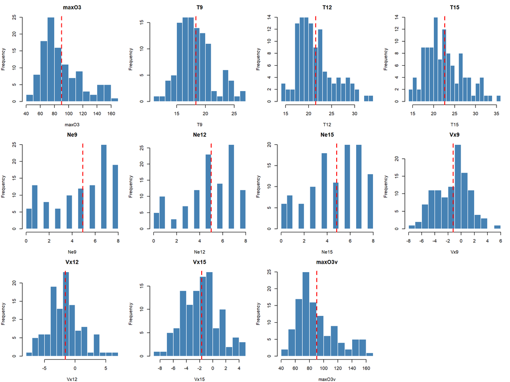

```r
par(mfrow = c(3, 4), mar = c(4, 4, 2.5, 1))
for (v in names(ozone)) {
  hist(ozone[[v]],
       main   = v,
       xlab   = v,
       col    = "steelblue",
       border = "white",
       breaks = 15)
  abline(v = mean(ozone[[v]]), col = "red", lwd = 2, lty = 2)
}
```

## 7.2 Boxplots comparatifs (variables centrées-réduites)

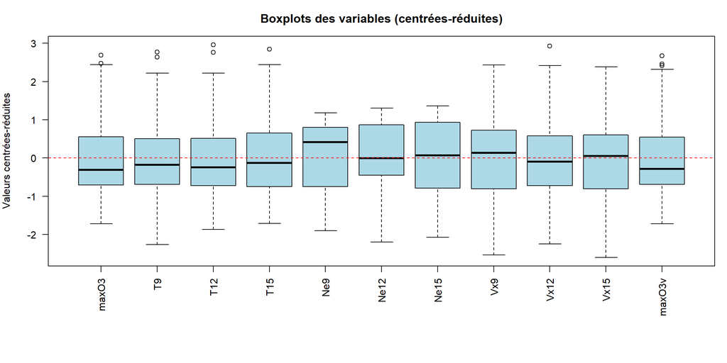

```r
par(mar = c(8, 4, 3, 1))
ozone_scaled <- as.data.frame(scale(ozone))
boxplot(ozone_scaled,
        main = "Boxplots des variables (centrées-réduites)",
        col  = "lightblue",
        las  = 2,
        ylab = "Valeurs centrées-réduites")
abline(h = 0, col = "red", lty = 2)
```

## 7.3 Focus sur la variable réponse maxO3

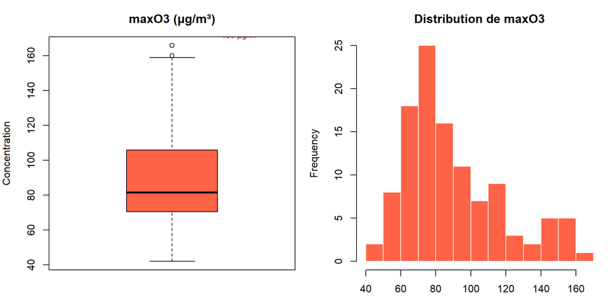

```r
par(mfrow = c(1, 2), mar = c(3, 4, 3, 1))

boxplot(ozone$maxO3,
        main = "maxO3 (μg/m³)",
        col  = "tomato",
        ylab = "Concentration")
abline(h = 180, col = "red", lwd = 2, lty = 2)
text(1.3, 175, "Seuil légal\n180 μg/m³", col = "red", cex = 0.8)

hist(ozone$maxO3,
     main   = "Distribution de maxO3",
     xlab   = "maxO3 (μg/m³)",
     col    = "tomato",
     breaks = 15,
     border = "white")
abline(v = 180, col = "red", lwd = 2, lty = 2)
```

# 8 Normalité de la variable réponse et transformation logarithmique

La distribution de `maxO3` apparaît **asymétrique à droite**. Or, même si la régression linéaire ne suppose pas la normalité de la variable réponse elle-même mais celle des **résidus**, une réponse fortement asymétrique génère souvent des résidus non normaux. On évalue donc l’intérêt d’une **transformation logarithmique** de `maxO3`.

On teste la distribution `maxO3`

## 8.1 Test de normalité (Shapiro-Wilk)

On teste l’hypothèse de normalité $H_0$ : la variable suit une loi normale sur `maxO3` brut puis après transformation log :

```r
# Coefficient d'asymétrie (skewness)
skewness <- function(x) mean((x - mean(x))^3) / sd(x)^3

normalite <- data.frame(
  Variable     = c("maxO3", "log(maxO3)"),
  Shapiro_W    = c(shapiro.test(ozone$maxO3)$statistic,
                   shapiro.test(log(ozone$maxO3))$statistic),
  Shapiro_pval = c(shapiro.test(ozone$maxO3)$p.value,
                   shapiro.test(log(ozone$maxO3))$p.value),
  Skewness     = c(skewness(ozone$maxO3),
                   skewness(log(ozone$maxO3)))
)
normalite$Shapiro_W    <- round(normalite$Shapiro_W, 4)
normalite$Shapiro_pval <- format.pval(normalite$Shapiro_pval, digits = 3)
normalite$Skewness     <- round(normalite$Skewness, 3)
normalite
```

| Variable | Shapiro_W | Shapiro_pval | Skewness |
| --- | --- | --- | --- |
| maxO3 | 0.9060 | 8.52e-07 | 0.983 |
| log(maxO3) | 0.9685 | 0.00951 | 0.374 |

**Lecture :**

- `maxO3` brut : $p < 10^{-5}$ → normalité **rejetée**confirme une forte asymétrie à droite.
- `log(maxO3)` : $p = 0.0095$.

  La normalité reste rejetée au seuil 5 %, mais on note une amélioration.

## 8.2 Comparaison graphique histogrammes et Q-Q plots

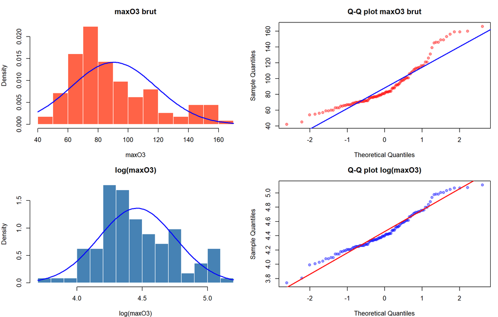

```r
par(mfrow = c(2, 2), mar = c(4, 4, 3, 1))

# Ligne 1 : maxO3 brut
hist(ozone$maxO3, breaks = 15, col = "tomato", border = "white",
     main = "maxO3 brut", xlab = "maxO3", freq = FALSE)
curve(dnorm(x, mean(ozone$maxO3), sd(ozone$maxO3)),
      add = TRUE, col = "blue", lwd = 2)
qqnorm(ozone$maxO3, main = "Q-Q plot maxO3 brut",
       pch = 19, col = rgb(1, 0, 0, 0.4))
qqline(ozone$maxO3, col = "blue", lwd = 2)

# Ligne 2 : log(maxO3)
hist(log(ozone$maxO3), breaks = 15, col = "steelblue", border = "white",
     main = "log(maxO3)", xlab = "log(maxO3)", freq = FALSE)
curve(dnorm(x, mean(log(ozone$maxO3)), sd(log(ozone$maxO3))),
      add = TRUE, col = "blue", lwd = 2)
qqnorm(log(ozone$maxO3), main = "Q-Q plot log(maxO3)",
       pch = 19, col = rgb(0, 0, 1, 0.4))
qqline(log(ozone$maxO3), col = "red", lwd = 2)
```

Le Q-Q plot de `log(maxO3)` (en bas) suit nettement mieux la droite de Henry que la version brute (en haut), qui décroche aux deux extrémités. La transformation log **symétrise** la distribution et **stabilise la variance**.

## 8.3 Confirmation par un test complémentaire (Kolmogorov-Smirnov)

Graphiquement, `log(maxO3)` semble nettement plus proche d’une loi normale. Pourtant le test de Shapiro-Wilk continue de rejeter la normalité ($p = 0.0095$). En cherchant on constate que **plusieurs tests de normalité existent** et qu’ils n’ont pas tous la même sensibilité : le test de Shapiro-Wilk est réputé être l’un des **plus puissants**, et donc l’un des plus prompts à rejeter $H_0$ dès qu’apparaît un écart, même minime, sur un échantillon de taille moyenne $n = 112$. Il reste donc important de confronter ce résultat à un **autre test**, afin de ne pas conclure sur la seule base d’une impression graphique.

On utilise le **test de Kolmogorov-Smirnov**, qui compare la fonction de répartition empirique des données à celle d’une loi normale de mêmes moyenne et écart-type :

```r
# Test de Kolmogorov-Smirnov contre une loi normale (données standardisées)
ks_brut <- ks.test(scale(ozone$maxO3), "pnorm")
ks_log  <- ks.test(scale(log(ozone$maxO3)), "pnorm")

ks_table <- data.frame(
  Variable = c("maxO3", "log(maxO3)"),
  KS_D     = round(c(ks_brut$statistic, ks_log$statistic), 4),
  KS_pval  = round(c(ks_brut$p.value, ks_log$p.value), 4)
)
ks_table
```

| Variable | KS_D | KS_pval |
| --- | --- | --- |
| maxO3 | 0.1599 | 0.0065 |
| log(maxO3) | 0.1099 | 0.1334 |

**Lecture :**

- `maxO3` brut : $p = 0.0065$ → normalité **rejetée**, en accord avec Shapiro-Wilk.
- `log(maxO3)` : $p = 0.133$ → on **ne rejette plus** la normalité au seuil 5 %.

Le test de Kolmogorov-Smirnov, moins sensible que Shapiro-Wilk, **confirme donc l’impression graphique** : après transformation logarithmique, la distribution de `maxO3` est compatible avec une loi normale.

## 8.4 Conclusion sur la transformation

La transformation logarithmique de `maxO3` améliore sensiblement la normalité et réduit l’asymétrie : l’impression graphique(Q-Q plot est confirmée par le test de Kolmogorov-Smirnov $p = 0.13$. Elle constitue donc une **piste sérieuse** pour la phase de modélisation : on pourra comparer les performances des modèles ajustés sur `maxO3` brut et sur `log(maxO3)`, en s’appuyant sur l’**analyse des résidus du modèle complet** pour trancher définitivement car c’est la normalité des résidus, et non celle de la réponse brute, qui conditionne la validité des tests du modèle linéaire.

# 9 Analyse des corrélations et de la multicolinéarité

Plutôt qu’une matrice unique de 11 variablesb illisible, on analyse les relations bloc par bloc. Chaque graphique croise un groupe de variables températures, nébulosités ou vent avec la réponse `maxO3`.

## 9.1 Températures

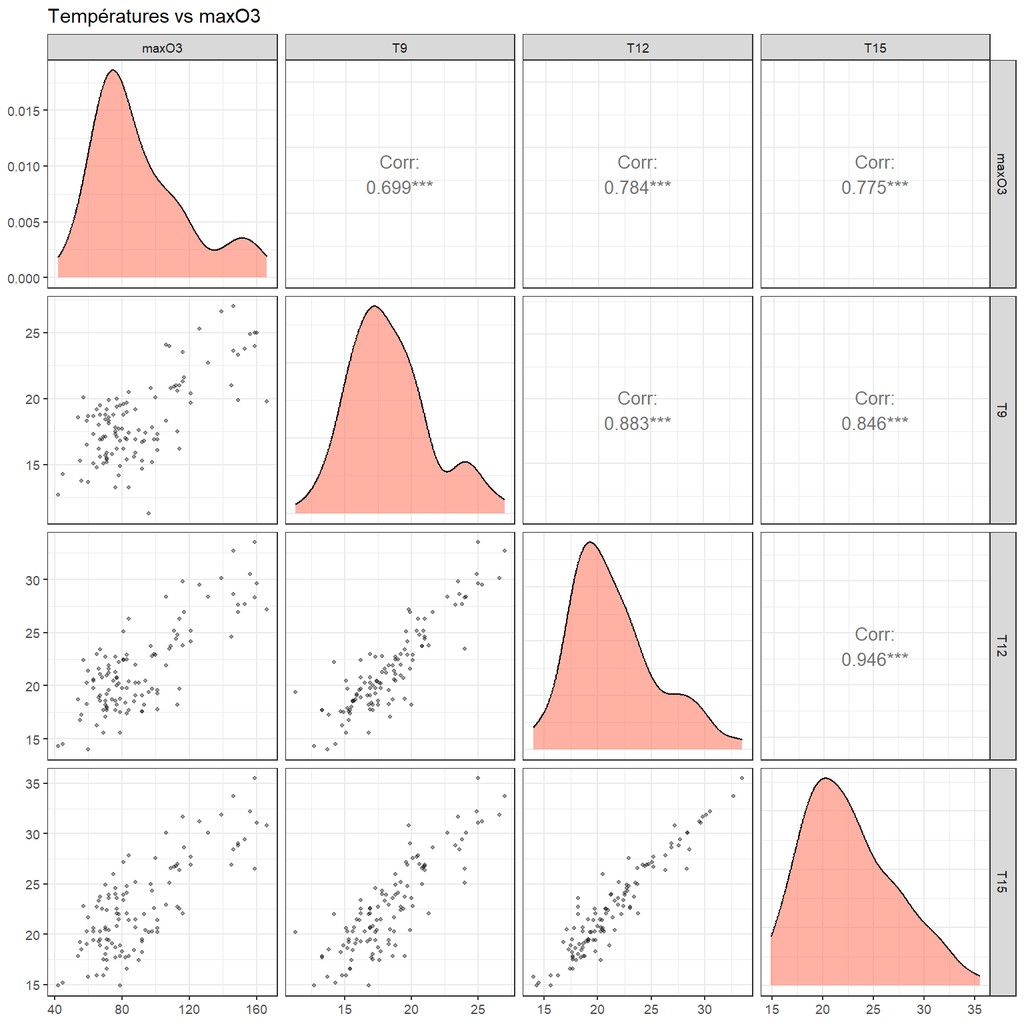

```r
ggpairs(ozone[, c("maxO3", "T9", "T12", "T15")],
        upper = list(continuous = wrap("cor", size = 3.5)),
        lower = list(continuous = wrap("points", alpha = 0.4, size = 0.8)),
        diag  = list(continuous = wrap("densityDiag", fill = "tomato", alpha = 0.5)),
        title = "Températures vs maxO3") +
  theme_bw(base_size = 9)
```

Les trois températures sont très fortement corrélées entre elles (jusqu’à 0.95 entre T12 et T15) et bien corrélées positivement à `maxO3` (0.70 à 0.78).

## 9.2 Nébulosités

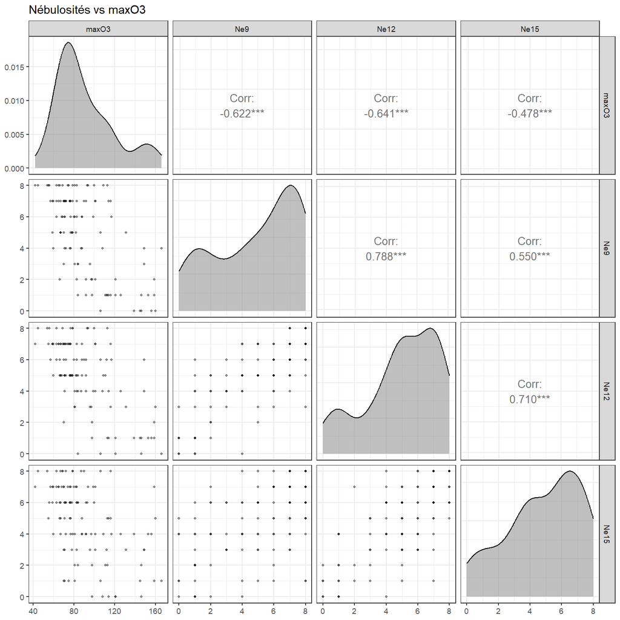

```r
ggpairs(ozone[, c("maxO3", "Ne9", "Ne12", "Ne15" )],
        upper = list(continuous = wrap("cor", size = 3.5)),
        lower = list(continuous = wrap("points", alpha = 0.4, size = 0.8)),
        diag  = list(continuous = wrap("densityDiag", fill = "gray50", alpha = 0.5)),
        title = "Nébulosités vs maxO3") +
  theme_bw(base_size = 9)
```

Les nébulosités sont corrélées entre elles (0.55 à 0.79) et liées **négativement** à `maxO3` (-0.48 à -0.64) : plus le ciel est couvert, moins l’ozone se forme.

## 9.3 Vent (composante E-O)

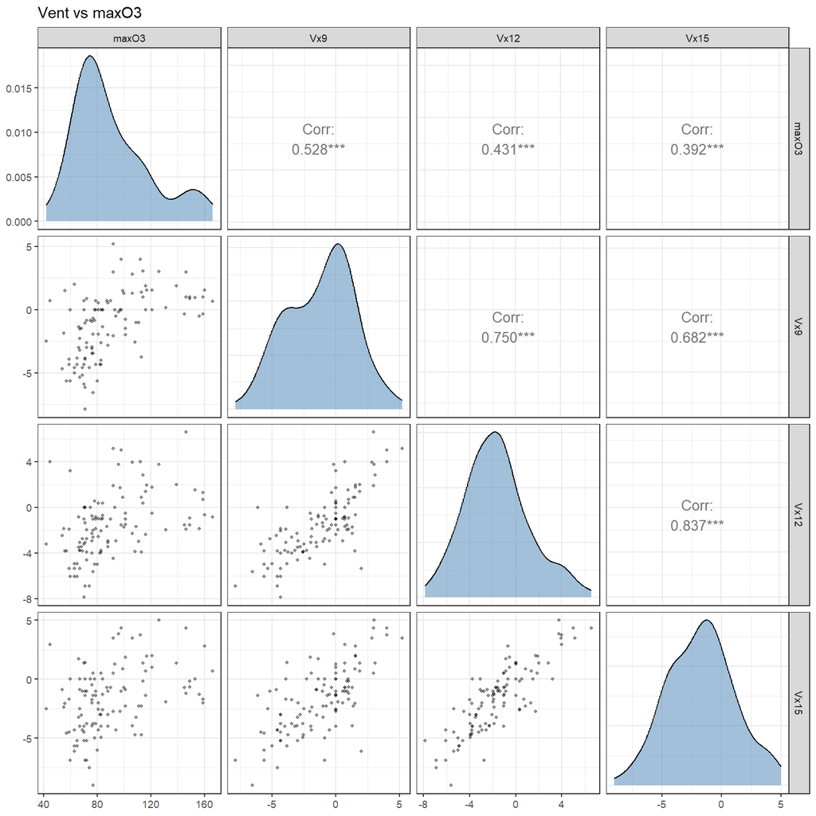

```r
ggpairs(ozone[, c("maxO3", "Vx9", "Vx12", "Vx15")],
        upper = list(continuous = wrap("cor", size = 3.5)),
        lower = list(continuous = wrap("points", alpha = 0.4, size = 0.8)),
        diag  = list(continuous = wrap("densityDiag", fill = "steelblue", alpha = 0.5)),
        title = "Vent vs maxO3") +
  theme_bw(base_size = 9)
```

Les composantes du vent sont corrélées entre elles (0.68 à 0.84) et liées positivement mais plus modérément à `maxO3` (0.39 à 0.53).

## 9.4 Bilan de la multicolinéarité

Les trois blocs de variables sont fortement autocorrélés en interne :

- **Températures** (T9, T12, T15) : corrélations entre 0.85 et 0.95
- **Nébulosités** (Ne9, Ne12, Ne15) : corrélations entre 0.55 et 0.79
- **Vent** (Vx9, Vx12, Vx15) : corrélations entre 0.68 et 0.84

Cette multicolinéarité s’explique simplement par le fait qu’il s’agit de la même grandeur physique mesurée à des horaires différents. Il est donc logique que la température à 9h soit fortement corrélée à celle de 12h, et il en va de même pour les nébulosités et les composantes du vent.

# 10 Analyse en Composantes Principales (ACP)

Pour explorer la structure multivariée du jeu de données, on réalise une ACP sur les **10 variables explicatives**, en plaçant **`maxO3`** en **variable supplémentaire quantitative**. Elle est ainsi projetée sur les axes factoriels sans influencer leur construction, ce qui permet d’observer sa relation aux prédicteurs.

```r
library(FactoMineR)
library(factoextra)
library(gridExtra)
```

## 10.1 Réalisation de l’ACP

```r
# maxO3 (colonne 1) en variable supplémentaire
# maxO3v reste ACTIVE car c'est une variable explicative du modèle
res_pca <- PCA(ozone,
               scale.unit = TRUE,
               quanti.sup = 1,
               graph = FALSE)
```

## 10.2 Choix du nombre de composantes

```r
round(res_pca$eig, 2)
```

```
##         eigenvalue percentage of variance cumulative percentage of variance
## comp 1        5.49                  54.94                             54.94
## comp 2        1.84                  18.45                             73.39
## comp 3        0.90                   8.98                             82.37
## comp 4        0.58                   5.78                             88.15
## comp 5        0.39                   3.94                             92.09
## comp 6        0.33                   3.32                             95.41
## comp 7        0.18                   1.82                             97.23
## comp 8        0.16                   1.59                             98.82
## comp 9        0.09                   0.86                             99.68
## comp 10       0.03                   0.32                            100.00
```

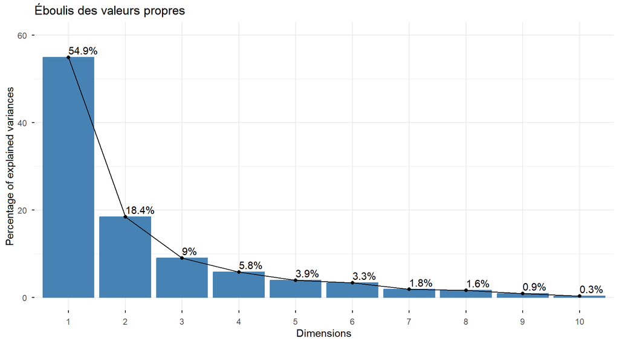

```r
fviz_eig(res_pca,
         addlabels = TRUE,
         ylim = c(0, 60),
         barfill = "steelblue",
         barcolor = "steelblue",
         main = "Éboulis des valeurs propres")
```

Les deux premiers axes expliquent **73 %** de la variance totale (54.9 % + 18.4 %).

## 10.3 Cercle des corrélations

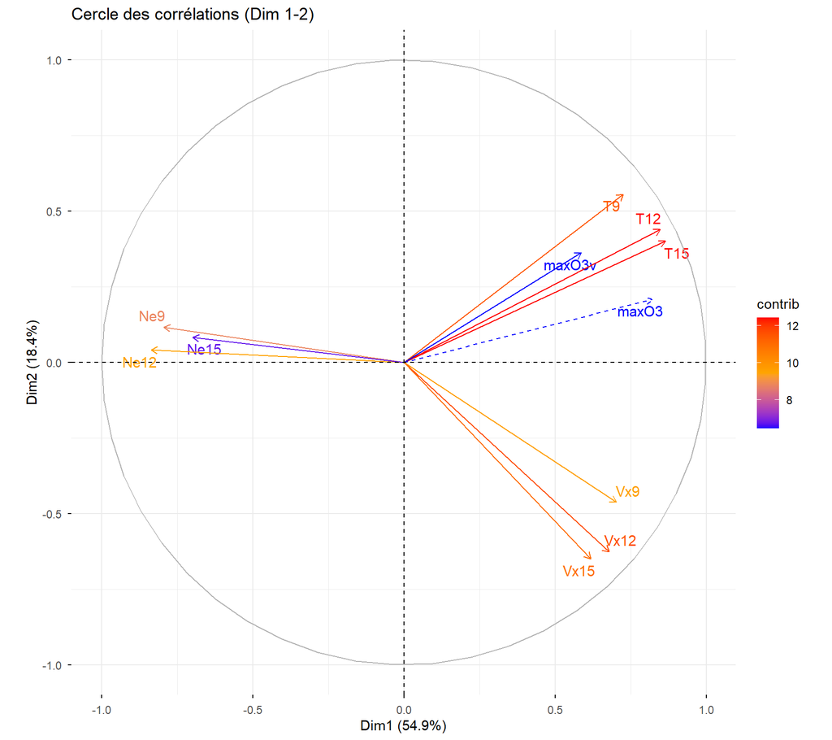

```r
fviz_pca_var(res_pca,
             col.var = "contrib",
             gradient.cols = c("blue", "orange", "red"),
             repel = TRUE,
             title = "Cercle des corrélations (Dim 1-2)")
```

## 10.4 Interprétation rigoureuse des axes

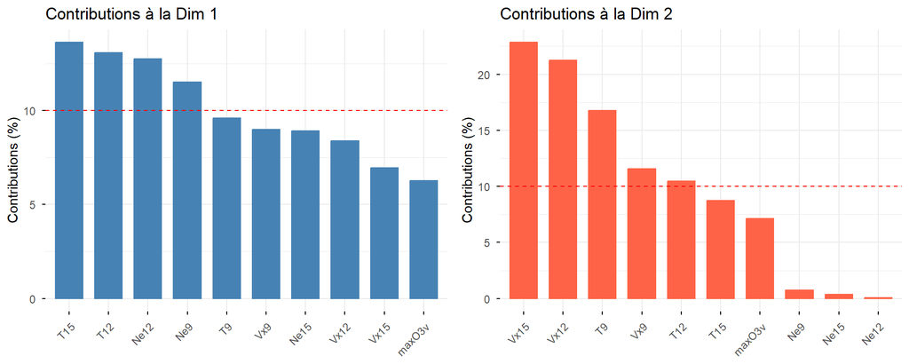

```r
g1 <- fviz_contrib(res_pca, choice = "var", axes = 1,
                   fill = "steelblue", color = "steelblue",
                   title = "Contributions à la Dim 1")
g2 <- fviz_contrib(res_pca, choice = "var", axes = 2,
                   fill = "tomato", color = "tomato",
                   title = "Contributions à la Dim 2")
grid.arrange(g1, g2, ncol = 2)
```

Pour interpréter le **signe** des axes, on compare les valeurs moyennes des variables sur les 10 individus situés aux extrêmes de chaque dimension :

```r
coord_ind <- res_pca$ind$coord

# Axe 1 : extrêmes droite vs gauche
idx_droite <- order(coord_ind[, 1], decreasing = TRUE)[1:10]
idx_gauche <- order(coord_ind[, 1], decreasing = FALSE)[1:10]

profils_axe1 <- rbind(
  "Dim1 +" = round(colMeans(ozone[idx_droite, ]), 1),
  "Dim1 -" = round(colMeans(ozone[idx_gauche, ]), 1)
)
profils_axe1
```

```
##        maxO3   T9  T12  T15 Ne9 Ne12 Ne15  Vx9 Vx12 Vx15 maxO3v
## Dim1 + 141.2 24.6 29.6 31.1 0.5  1.2  2.5  1.5  1.3  1.4  127.2
## Dim1 -  67.6 16.3 17.5 17.5 7.5  7.5  7.4 -4.5 -4.6 -4.6   68.4
```

```r
# Axe 2 : extrêmes haut vs bas
idx_haut <- order(coord_ind[, 2], decreasing = TRUE)[1:10]
idx_bas  <- order(coord_ind[, 2], decreasing = FALSE)[1:10]

profils_axe2 <- rbind(
  "Dim2 +" = round(colMeans(ozone[idx_haut, ]), 1),
  "Dim2 -" = round(colMeans(ozone[idx_bas, ]), 1)
)
profils_axe2
```

```
##        maxO3   T9  T12 T15 Ne9 Ne12 Ne15  Vx9 Vx12 Vx15 maxO3v
## Dim2 +  96.7 21.3 24.7  26 5.2  4.7  4.8 -3.4 -3.8 -4.8  107.1
## Dim2 -  81.6 15.0 18.1  19 3.0  4.8  4.7  1.1  2.5  2.1   80.4
```

**Axe 1 (54.9 %) — gradient météorologique global**

À droite : journées **chaudes** (T15 ≈ 31 °C), **peu nuageuses** (Ne12 ≈ 1), avec vent d’Ouest. À gauche : journées **fraîches** (T15 ≈ 17 °C), **très nuageuses** (Ne12 ≈ 7.5), avec vent d’Est .

**Axe 2 (18.4 %) — opposition chaleur stagnante / vent océanique**

En haut : journées **chaudes** (T9 ≈ 21 °C) sans vent d’Ouest (Vx15 ≈ −5, donc plutôt vent d’Est). En bas : journées **fraîches** (T9 ≈ 15 °C) avec vent d’Ouest (Vx15 ≈ +2).

## 10.5 Position maxO3 sur les axes

```r
cat("\n--- Coordonnées de maxO3 (supplémentaire) ---\n")
```

```
##
## --- Coordonnées de maxO3 (supplémentaire) ---
```

```r
round(res_pca$quanti.sup$coord[, 1:3], 3)
```

```
## Dim.1 Dim.2 Dim.3
## 0.822 0.209 0.141
```

```r
cat("\n--- Cosinus² de maxO3 ---\n")
```

```
##
## --- Cosinus² de maxO3 ---
```

```r
round(res_pca$quanti.sup$cos2[, 1:3], 3)
```

```
## Dim.1 Dim.2 Dim.3
## 0.675 0.044 0.020
```

`maxO3` est très bien représentée par l’axe 1 (cos² = 0.68) et faiblement par les autres axes.

## 10.6 Carte des individus colorée par maxO3

```
## Ignoring unknown labels:
## • fill : "maxO3"
## • linetype : "maxO3"
## • shape : "maxO3"
```

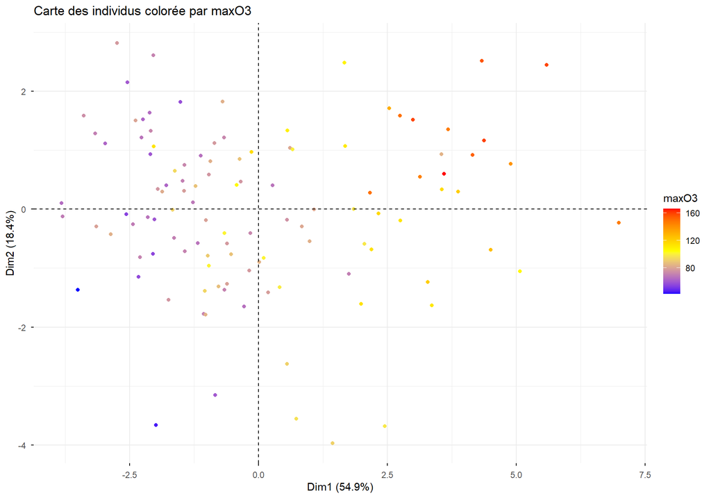

```r
fviz_pca_ind(res_pca,
             col.ind = ozone$maxO3,
             gradient.cols = c("blue", "yellow", "red"),
             label = "none",
             legend.title = "maxO3",
             title = "Carte des individus colorée par maxO3")
```

Le **dégradé de couleurs** sur l’axe 1 valide visuellement les conclusions précédentes : les journées à forte concentration d’ozone (rouge) sont à droite, celles à faible concentration (bleu) à gauche. La séparation est nette et continue, sans groupes distincts.

## 10.7 Test de significativité de la projection de maxO3

```r
resultats_test <- sapply(1:5, function(k) {
  test <- cor.test(ozone$maxO3, res_pca$ind$coord[, k])

  c(
    r       = test$estimate,
    p.value = test$p.value
  )
})

t(resultats_test)
```

```
##            r.cor      p.value
## [1,]  0.82155452 1.320983e-28
## [2,]  0.20917939 2.686597e-02
## [3,]  0.14071886 1.389010e-01
## [4,] -0.05918018 5.353752e-01
## [5,] -0.12511694 1.887014e-01
```

**Lecture du tableau :**

- **Dim 1** : $p = 1.3e-28$ avec 110 ddl, $p < 10^{-16}$ → corrélation **hautement significative** ($H_0$ rejetée).
- **Dim 2** : $p = 0.027$ **significative** au seuil 5 %, mais bien plus faible.
- **Dim 3 à 5** : $p > 0.05$ **non significatives**.

## 10.8 Bilan de l’ACP

- **73 % de variance** sur les deux premiers axes : excellente synthèse
- **Axe 1** = gradient chaud/sec ↔︎ frais/nuageux
- **Axe 2** = chaleur stagnante ↔︎ fraîcheur ventilée
- **`maxO3` très bien projetée** sur Dim 1

# 11 Le problème de la grande dimension

On se met volontairement en difficulté en ne gardant que les **10 premières lignes** pour estimer le modèle. Avec 10 prédicteurs et l’intercept, ça fait 11 paramètres à caler sur 10 observations seulement : on bascule dans le cas $p+1 > n$, c’est-à-dire la grande dimension.

```r
ozone10 <- ozone[1:10, ]      # sous-échantillon d'apprentissage
reste   <- ozone[-(1:10), ]   # les autres jours, pour la prévision

cat("Apprentissage :", nrow(ozone10), "observations pour",
    ncol(ozone10) - 1, "prédicteurs (", ncol(ozone10), "paramètres)\n")
```

```
## Apprentissage : 10 observations pour 10 prédicteurs ( 11 paramètres)
```

## 11.1 Régression complète sur 10 observations

```r
mod10 <- lm(maxO3 ~ ., data = ozone10)
summary(mod10)
```

```
##
## Call:
## lm(formula = maxO3 ~ ., data = ozone10)
##
## Residuals:
## ALL 10 residuals are 0: no residual degrees of freedom!
##
## Coefficients: (1 not defined because of singularities)
##             Estimate Std. Error t value Pr(>|t|)
## (Intercept) -245.877        NaN     NaN      NaN
## T9            -1.385        NaN     NaN      NaN
## T12           12.520        NaN     NaN      NaN
## T15            6.204        NaN     NaN      NaN
## Ne9            9.265        NaN     NaN      NaN
## Ne12          -5.283        NaN     NaN      NaN
## Ne15           5.716        NaN     NaN      NaN
## Vx9          -14.401        NaN     NaN      NaN
## Vx12          21.975        NaN     NaN      NaN
## Vx15           7.708        NaN     NaN      NaN
## maxO3v            NA         NA      NA       NA
##
## Residual standard error: NaN on 0 degrees of freedom
## Multiple R-squared:      1,  Adjusted R-squared:    NaN
## F-statistic:   NaN on 9 and 0 DF,  p-value: NA
```

Le `summary` montre déjà $R^2 = 1$ et un $R^2_{aj}$ indéterminé (`NaN`). On calcule explicitement les autres critères pour confirmer leur effondrement :

```r
data.frame(
  Critere = c("R2", "R2 ajuste", "Somme carres residus (SCres)",
              "Sigma residuel", "AIC", "BIC"),
  Valeur  = c(summary(mod10)$r.squared,
              summary(mod10)$adj.r.squared,
              sum(residuals(mod10)^2),
              summary(mod10)$sigma,
              AIC(mod10),
              BIC(mod10))
)
```

| Critere | Valeur |
| --- | --- |
| R2 | 1 |
| R2 ajuste | NaN |
| Somme carres residus (SCres) | 0 |
| Sigma residuel | NaN |
| AIC | -Inf |
| BIC | -Inf |

Dès qu’on a plus de paramètres que d’observations ($p+1 > n$), le système $y = X\beta + e$ admet une infinité de solutions : il y a trop d’inconnues pour le nombre d’équations, donc l’estimateur MCO $\hat\beta$ n’est plus unique.

Comme le modèle a assez de liberté pour passer exactement par les 10 points, on a $\hat{y} = y$ : la somme des carrés des résidus est **nulle** ($SC_{res} = 0$, sigma `NaN`) et il ne reste aucun degré de liberté. Tous les indicateurs qui s’appuient sur ces résidus s’effondrent, exactement comme prévu dans le cas $p+1 > n$ :

| Critère | Cas $p+1>n$ | Valeur calculée |
| --- | --- | --- |
| $R^2$ | $1$ | $1$ |
| $R^2_{aj} = 1 - \frac{SC_{res}/(n-(p+1))}{SC_{tot}/(n-1)}$ | indéfini car $n-(p+1)<0$ | `NaN` |
| $C_p$ de Mallows $= \frac{SC_{res}}{s^2} + 2(k+1) - n$ | indéfini car $s^2 = 0$ (division par 0) | non calculable |
| AIC $= n\ln(SC_{res}/n) + 2(k+1)$ | $-\infty$ car $\ln(0) = -\infty$ | $-\infty$ |
| BIC $= n\ln(SC_{res}/n) + (\ln n)(k+1)$ | $-\infty$ | $-\infty$ |

Pour le $C_p$ comme pour l’AIC/BIC, le problème vient de $SC_{res} = 0$ : l’AIC et le BIC contiennent un $\ln(SC_{res})$ qui vaut $-\infty$, et le $C_p$ divise par $s^2 = 0$. Aucun de ces critères n’est donc exploitable.

Le $R^2=1$ ne veut donc pas dire que le modèle est bon : c’est juste qu’il a appris les 10 points, sans rien comprendre.

## 11.2 Qualité des prévisions sur les autres jours

```r
pred_reste <- predict(mod10, newdata = reste)
rmse_complet <- sqrt(mean((reste$maxO3 - pred_reste)^2))

cat("RMSE du modèle complet sur les", nrow(reste), "autres jours :",
    round(rmse_complet, 1), "\n")
```

```
## RMSE du modèle complet sur les 102 autres jours : 100.1
```

```r
cat("Écart-type de maxO3 (référence) :", round(sd(ozone$maxO3), 1), "\n")
```

```
## Écart-type de maxO3 (référence) : 28.2
```

Et ça se vérifie sur les jours qu’on a mis de côté : le RMSE grimpe à **≈ 100 µg/m³**, presque **3,5 fois l’écart-type** de maxO3 (28 µg/m³). Prédire avec ce modèle revient à faire pire que de répondre bêtement la moyenne à chaque jour. L’ajustement parfait sur le train ne sert strictement à rien en prévision.

## 11.3 Solution : réduire la dimension par sélection forward

Pour s’en sortir, on s’appuie sur un modéle réduit : on suppose que seuls quelques coefficients $p^* \ll n$ comptent vraiment, et on essaie de retrouver ce petit sous-modèle. Reste à choisir la méthode de sélection : ici backward et stepwise ne démarrent même pas car elles partent du modèle complet, dont l’AIC vaut $-\infty$. La seule qui fonctionne est la **forward**, qui part du modèle vide et ajoute les variables une à une.

```r
mod_null <- lm(maxO3 ~ 1, data = ozone10)
mod_fwd  <- step(mod_null, scope = formula(mod10),
                 direction = "forward", trace = FALSE)

cat("Modèle retenu :", deparse(formula(mod_fwd)), "\n")
```

```
## Modèle retenu : maxO3 ~ T15 + maxO3v
```

```r
summary(mod_fwd)
```

```
##
## Call:
## lm(formula = maxO3 ~ T15 + maxO3v, data = ozone10)
##
## Residuals:
##    Min     1Q Median     3Q    Max
## -7.504 -2.671 -1.155  2.855  7.804
##
## Coefficients:
##             Estimate Std. Error t value Pr(>|t|)
## (Intercept)  17.1665    18.7146   0.917 0.389505
## T15           4.9823     0.8525   5.844 0.000634 ***
## maxO3v       -0.2508     0.1849  -1.356 0.217151
## ---
## Signif. codes:  0 '***' 0.001 '**' 0.01 '*' 0.05 '.' 0.1 ' ' 1
##
## Residual standard error: 5.705 on 7 degrees of freedom
## Multiple R-squared:  0.8335, Adjusted R-squared:  0.7859
## F-statistic: 17.52 on 2 and 7 DF,  p-value: 0.001884
```

```r
# Prévision du modèle réduit sur les autres jours
pred_fwd <- predict(mod_fwd, newdata = reste)
rmse_fwd <- sqrt(mean((reste$maxO3 - pred_fwd)^2))
cat("RMSE du modèle réduit sur les autres jours :", round(rmse_fwd, 1), "\n")
```

```
## RMSE du modèle réduit sur les autres jours : 28.5
```

La forward s’arrête sur un modèle à 2 variables, `T15 + maxO3v`. Cette fois il reste des degrés de liberté (10 obs 3 paramètres = 7), donc le $R^2_{aj}$ redevient calculable (0,79) et les tests ont un sens. Surtout, le RMSE en prévision retombe à **28,5 µg/m³** : on est revenu au niveau de l’écart-type, là où le modèle complet plafonnait à 100. Sur si peu de données, seul T15 ressort vraiment significatif (maxO3v non, faute de puissance), mais l’essentiel est là : un petit modèle prédit bien mieux que le gros.

## 11.4 Vérification des hypothèses du modèle réduit

```r
library(lmtest)
res_fwd <- residuals(mod_fwd)
```

### 11.4.1 Linéarité — test de Harvey-Collier

- **H₀** : la relation est linéaire
- **H₁** : la relation n’est pas linéaire

```r
harvtest(mod_fwd)
```

```
##
##  Harvey-Collier test
##
## data:  mod_fwd
## HC = 0.33858, df = 6, p-value = 0.7465
```

p = 0,746 > 0,05 : on ne rejette pas H₀. **La linéarité est validée.**

### 11.4.2 Homoscédasticité — test de Breusch-Pagan

- **H₀** : la variance des résidus est constante (homoscédasticité)
- **H₁** : la variance n’est pas constante (hétéroscédasticité)

```r
bptest(mod_fwd)
```

```
##
##  studentized Breusch-Pagan test
##
## data:  mod_fwd
## BP = 0.61291, df = 2, p-value = 0.7361
```

p = 0,736 > 0,05 : on ne rejette pas H₀. **L’homoscédasticité est validée.**

### 11.4.3 Indépendance — test de Durbin-Watson

- **H₀** : les résidus ne sont pas autocorrélés
- **H₁** : les résidus sont autocorrélés

```r
dwtest(mod_fwd)
```

```
##
##  Durbin-Watson test
##
## data:  mod_fwd
## DW = 2.6137, p-value = 0.811
## alternative hypothesis: true autocorrelation is greater than 0
```

DW = 2,61 et p = 0,811 > 0,05 : on ne rejette pas H₀. **L’indépendance est validée.**

### 11.4.4 Normalité — test de Kolmogorov-Smirnov

- **H₀** : les résidus suivent une loi normale
- **H₁** : les résidus ne suivent pas une loi normale

```r
ks.test(scale(res_fwd), "pnorm")
```

```
##
##  Exact one-sample Kolmogorov-Smirnov test
##
## data:  scale(res_fwd)
## D = 0.1946, p-value = 0.7763
## alternative hypothesis: two-sided
```

p = 0,776 > 0,05 : on ne rejette pas H₀. **La normalité est validée.**

## 11.5 Vérification de la multicolinéarité (VIF)

```r
library(car)
vif(mod_fwd)
```

```
##      T15   maxO3v
## 1.169786 1.169786
```

Les VIF des deux variables retenues valent 1,17 — très proches de 1, donc aucune multicolinéarité résiduelle: le seuil d’alerte est 5, voire 10. La sélection forward a donc bien produit un modèle sain de ce point de vue.

## 11.6 Conclusion

Le constat est net : tant qu’on a $p+1 > n$, le modèle complet est ingérable et ne prédit rien. Il faut réduire la dimension via forward comme ici, ou par les approches qu’on explore dans la suite :régressions PCR, PLS.

# 12 Régression sur composantes principales (PCR)

Face à la multicolinéarité, la PCR *Principal Component Regression* propose une alternative : plutôt que de régresser sur les variables d’origine, on régresse sur leurs **composantes principales**. On choisit ensuite le nombre de composantespar validation croisée, en minimisant l’erreur de prévision RMSEP.

## 12.1 Séparation train / test

Pour évaluer honnêtement les performances de prévision, on partage les données en un échantillon d’apprentissage **70 %** et un échantillon de test **30 %**.

```r
library(pls)
set.seed(42)
n <- nrow(ozone)
idx_train <- sample(1:n, size = round(0.7 * n))
train <- ozone[idx_train, ]
test  <- ozone[-idx_train, ]

cat("Apprentissage :", nrow(train), "observations\n")
```

```
## Apprentissage : 78 observations
```

```r
cat("Test          :", nrow(test), "observations\n")
```

```
## Test          : 34 observations
```

## 12.2 Ajustement de la PCR

On ajuste la PCR sur l’échantillon d’apprentissage, nombre de composantes choisi par **validation croisée**.

```r
set.seed(42)
mod_pcr <- pcr(maxO3 ~ ., data = train, scale = TRUE, validation = "CV")
summary(mod_pcr)
```

```
## Data:    X dimension: 78 10
##  Y dimension: 78 1
## Fit method: svdpc
## Number of components considered: 10
##
## VALIDATION: RMSEP
## Cross-validated using 10 random segments.
##        (Intercept)  1 comps  2 comps  3 comps  4 comps  5 comps  6 comps
## CV           26.75    16.28    14.98    14.51    14.74    15.31    14.43
## adjCV        26.75    16.26    14.95    14.34    14.70    15.27    14.35
##        7 comps  8 comps  9 comps  10 comps
## CV       14.46    14.60    14.93     15.43
## adjCV    14.37    14.51    14.82     15.30
##
## TRAINING: % variance explained
##        1 comps  2 comps  3 comps  4 comps  5 comps  6 comps  7 comps  8 comps
## X        56.42    75.04    82.56    89.65    93.19    96.26    97.90    99.24
## maxO3    63.87    69.74    72.46    72.69    73.09    75.53    76.08    76.12
##        9 comps  10 comps
## X        99.76    100.00
## maxO3    76.18     76.22
```

La variance de `maxO3` expliquée croît vite puis stagne : **64 %** dès la 1re composante, **72 %** dès la 3e, et la progression devient ensuite très lente. Côté prédicteurs, les premières composantes concentrent l’essentiel de l’information.

## 12.3 Choix du nombre de composantes

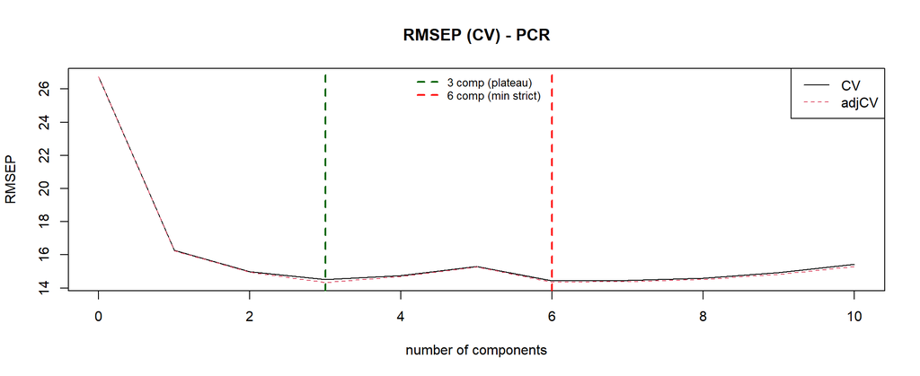

```r
validationplot(mod_pcr, val.type = "RMSEP",
               main = "RMSEP (CV) - PCR", legendpos = "topright")
abline(v = 3, col = "darkgreen", lty = 2, lwd = 2)
abline(v = 6, col = "red", lty = 2, lwd = 2)
legend("top", legend = c("3 comp (plateau)", "6 comp (min strict)"),
       col = c("darkgreen", "red"), lty = 2, lwd = 2, bty = "n", cex = 0.8)
```

Le RMSEP en validation croisée chute fortement jusqu’à la 3e composante 14.51, puis **oscille** entre 14.4 et 15.3 sans tendance nette. Le **minimum strict** est atteint à **6 composantes** 14.43, mais il ne devance la solution à 3 composantes que de 0.08 µg/m³ un écart négligeable.

Deux lectures sont donc possibles :

- **Critère strict** : on retient le nombre de composantes minimisant le RMSEP, soit **6 composantes**.
- **Critère de parcimonie** : la quasi-totalité du gain étant acquise dès la **3ᵉ composante**, et la courbe formant un plateau au-delà, un modèle à 3 composantes offre une performance équivalente avec deux fois moins de dimensions et une meilleure interprétabilité.

La solution à **3 composantes** apparaît plus fidèle à l’esprit de la méthode.

## 12.4 Erreur de prévision sur l’échantillon test

```r
pred_all <- predict(mod_pcr, newdata = test)
rmsep_test <- sapply(c(3, 6), function(k) {
  sqrt(mean((test$maxO3 - pred_all[, , k])^2))
})
data.frame(
  Composantes = c(3, 6),
  RMSEP_test  = round(rmsep_test, 2)
)
```

| Composantes | RMSEP_test |
| --- | --- |
| 3 | 16.16 |
| 6 | 16.79 |

Sur l’échantillon test indépendant, la solution à **3 composantes** atteint un RMSEP de **16.16 µg/m³**, légèrement **meilleur** que celle à 6 composantes 16.79. Cela confirme que les composantes supplémentaires n’apportent rien en généralisation.

## 12.5 Coefficients du modèle retenu

```r
# Coefficients pour le nombre optimal de composantes
coef_opt_pcr <- drop(coef(mod_pcr, ncomp = 3))

# Tri par importance
coef_opt_pcr_sorted <- coef_opt_pcr[order(abs(coef_opt_pcr), decreasing = TRUE)]
round(coef_opt_pcr_sorted, 4)
```

```
##      T9  maxO3v     T12     T15     Vx9    Vx12    Vx15     Ne9    Ne12    Ne15
##  5.7058  5.6976  5.3076  5.0344  1.9050  1.5357  1.2561 -0.8815 -0.8357 -0.4369
```

Les coefficients PCR confirment les analyses précédentes : `maxO3v` et les **températures** (T12, T15, T9) pèsent le plus positivement, tandis que la **nébulosité** (Ne9) joue négativement. On retrouve plus ou moins les mêmes variables dominantes que dans le modèle réduit obtenu par sélection pas à pas.

## 12.6 Bilan PCR

La PCR illustre l’intérêt de la réduction de dimension face à la multicolinéarité. Le critère du RMSEP en validation croisée désigne formellement 6 composantes, mais une solution plus parcimonieuse est quasi similaire sur le train c’elle à **3 composantes** est une meilleur solution.

# 13 Régression sur composantes : PLS

Nous appliquons ici une régression PLS pour modéliser `maxO3` en fonction des variables quantitatives. Contrairement à la PCR, qui construit ses composantes sans tenir compte de la réponse, la PLS construit des composantes qui **maximisent la covariance avec `maxO3`**.

## 13.1 Séparation des données (Train / Test)

On réutilise **le même découpage que pour la PCR** `train` / `test`, 70/30 , afin que les deux méthodes soient strictement comparables.

```r
# Rappel : train et test ont été définis dans la section PCR
cat("Échantillon Train :", nrow(train), "observations\n")
```

```
## Échantillon Train : 78 observations
```

```r
cat("Échantillon Test  :", nrow(test), "observations\n")
```

```
## Échantillon Test  : 34 observations
```

## 13.2 Ajustement du modèle PLS

```r
set.seed(42)
mod_pls <- plsr(maxO3 ~ ., data = train, scale = TRUE, validation = "CV")
summary(mod_pls)
```

```
## Data:    X dimension: 78 10
##  Y dimension: 78 1
## Fit method: kernelpls
## Number of components considered: 10
##
## VALIDATION: RMSEP
## Cross-validated using 10 random segments.
##        (Intercept)  1 comps  2 comps  3 comps  4 comps  5 comps  6 comps
## CV           26.75    15.37    14.46    14.58    14.75    14.84    15.11
## adjCV        26.75    15.35    14.43    14.51    14.66    14.74    14.99
##        7 comps  8 comps  9 comps  10 comps
## CV       15.35    15.43    15.42     15.43
## adjCV    15.23    15.29    15.28     15.30
##
## TRAINING: % variance explained
##        1 comps  2 comps  3 comps  4 comps  5 comps  6 comps  7 comps  8 comps
## X        56.00    73.35    81.18    85.47    87.88    93.84    96.40    98.32
## maxO3    68.23    73.40    75.49    76.10    76.18    76.19    76.21    76.22
##        9 comps  10 comps
## X        99.21    100.00
## maxO3    76.22     76.22
```

## 13.3 Choix du nombre de composantes (RMSEP par validation croisée)

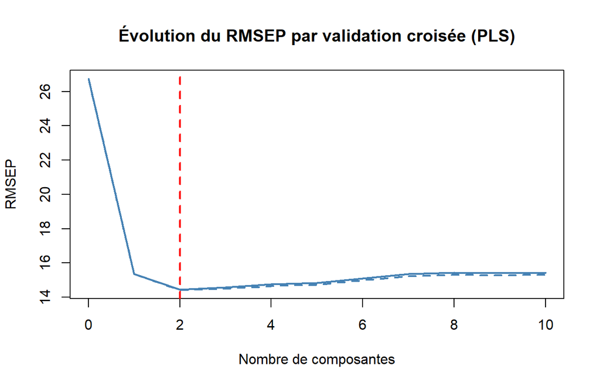

```r
validationplot(mod_pls, val.type = "RMSEP",
               main = "Évolution du RMSEP par validation croisée (PLS)",
               xlab = "Nombre de composantes",
               ylab = "RMSEP",
               col = "steelblue", lwd = 2)
abline(v = 2, col = "red", lty = 2, lwd = 2)
```

```r
rmsep_cv_pls <- RMSEP(mod_pls, estimate = "CV")$val[1, 1, ]
data.frame(Composantes = 0:10, RMSEP_CV = round(rmsep_cv_pls, 2))
```

|  | Composantes | RMSEP_CV |
| --- | --- | --- |
| (Intercept) | 0 | 26.75 |
| 1 comps | 1 | 15.37 |
| 2 comps | 2 | 14.46 |
| 3 comps | 3 | 14.58 |
| 4 comps | 4 | 14.75 |
| 5 comps | 5 | 14.84 |
| 6 comps | 6 | 15.11 |
| 7 comps | 7 | 15.35 |
| 8 comps | 8 | 15.43 |
| 9 comps | 9 | 15.42 |

[output cut: 1 more lines]

Le RMSEP en validation croisée atteint son minimum dès **2 composantes** 14.46, puis remonte. La PLS est donc nettement plus parcimonieuse que la PCR : 2 composantes PLS suffisent là où la PCR en demandait davantage, car chaque composante PLS est construite pour expliquer au mieux `maxO3`.

## 13.4 Erreur de prévision sur l’échantillon test

```r
# Prédiction sur le test pour 1 à 10 composantes (array 3D)
pred_pls <- predict(mod_pls, newdata = test, ncomp = 1:10)

# RMSEP sur le test pour chaque nombre de composantes
rmsep_test_pls <- sqrt(apply((pred_pls - test$maxO3)^2, 3, mean))
round(rmsep_test_pls, 2)
```

```
##  1 comps  2 comps  3 comps  4 comps  5 comps  6 comps  7 comps  8 comps
##    16.43    16.21    16.67    17.09    17.34    17.32    17.41    17.54
##  9 comps 10 comps
##    17.47    17.45
```

```r
# Nombre optimal minimisant le RMSEP test
ncomp_opt_pls <- which.min(rmsep_test_pls)
rmsep_min_pls <- min(rmsep_test_pls)
cat("\nNombre optimal de composantes (PLS) :", ncomp_opt_pls, "\n")
```

```
##
## Nombre optimal de composantes (PLS) : 2
```

```r
cat("RMSEP minimal sur le test :", round(rmsep_min_pls, 2), "\n")
```

```
## RMSEP minimal sur le test : 16.21
```

Sur l’échantillon test, le RMSEP est également minimal à **2 composantes** (16.21 μg/m³). Validation croisée et échantillon test concordent.

## 13.5 Coefficients du modèle retenu

```r
# Coefficients pour le nombre optimal de composantes
coef_opt_pls <- drop(coef(mod_pls, ncomp = ncomp_opt_pls))

# Tri par importance (valeur absolue)
coef_opt_pls_sorted <- coef_opt_pls[order(abs(coef_opt_pls), decreasing = TRUE)]
round(coef_opt_pls_sorted, 4)
```

```
##  maxO3v     T12     T15      T9     Ne9     Vx9    Ne12    Ne15    Vx15    Vx12
##  6.0253  5.1302  4.8975  4.8402 -2.6767  2.2485 -1.6396 -0.9645 -0.7691  0.2657
```

Les coefficients PLS confirment les analyses précédentes : `maxO3v` et les **températures** (T12, T15, T9) pèsent le plus positivement, tandis que la **nébulosité** (Ne9) joue négativement. On retrouve les mêmes variables dominantes que dans le modèle réduit obtenu par sélection pas à pas.

## 13.6 Bilan PLS

La PLS atteint un RMSEP de **16.2 μg/m³** sur le test avec seulement **2 composantes**, contre 16.16 μg/m³ pour la PCR avec 3 composantes. À performance comparable, la PLS est donc **plus parcimonieuse** et son choix de composantes plus stable

# 14 Tableau comparatif des méthodes

On rassemble enfin les erreurs de prévision (RMSEP) des différentes méthodes mises en œuvre, afin de conclure sur leurs mérites respectifs.

```r
# Modèle réduit issu de la partie grande dimension
# (entraîné sur les 10 premières lignes, testé sur les 102 autres)
ozone10 <- ozone[1:10, ]
reste   <- ozone[-(1:10), ]
mod_fwd <- step(lm(maxO3 ~ 1, data = ozone10),
                scope = formula(lm(maxO3 ~ ., data = ozone10)),
                direction = "forward", trace = FALSE)
rmse_fwd <- sqrt(mean((reste$maxO3 - predict(mod_fwd, reste))^2))

# PCR et PLS (entraînés sur train 70 %, testés sur test 30 %)
rmse_pcr <- sqrt(mean((test$maxO3 - predict(mod_pcr, test, ncomp = 3))^2))
rmse_pls <- sqrt(mean((test$maxO3 - predict(mod_pls, test, ncomp = 2))^2))

recap <- data.frame(
  Methode        = c("Modèle réduit (grande dim.)", "PCR", "PLS"),
  Specification  = c("T15 + maxO3v (2 var.)", "3 composantes", "2 composantes"),
  Protocole_test = c("10 lignes -> 102 autres", "train 70% -> test 30%",
                     "train 70% -> test 30%"),
  RMSEP          = round(c(rmse_fwd, rmse_pcr, rmse_pls), 2)
)
recap
```

| Methode | Specification | Protocole_test | RMSEP |
| --- | --- | --- | --- |
| Modèle réduit (grande dim.) | T15 + maxO3v (2 var.) | 10 lignes -> 102 autres | 28.50 |
| PCR | 3 composantes | train 70% -> test 30% | 16.16 |
| PLS | 2 composantes | train 70% -> test 30% | 16.21 |

Le modèle réduit issu de la partie grande dimension n’est **pas évalué sur le même échantillon test** que la PCR et la PLS. Son RMSEP n’est donc pas directement comparable et n’est fourni qu’à titre **indicatif**.

- La **PCR** et la **PLS**, qui exploitent les 10 prédicteurs sous forme de composantes, atteignent un RMSEP d’environ **16 µg/m³**, avec un très léger avantage en parcimonie pour la PLS (2 composantes contre 3).
- Le modèle réduit en grande dimension affiche un RMSEP plus élevé (**28,5 µg/m³**), ce qui s’explique avant tout par son protocole défavorable de seulement 10 observations pour l’apprentissage plutôt que par une faiblesse intrinsèque de la sélection de variables.

Sur ce jeu de données, les méthodes sur composantes et en particulier la **PLS** constituent donc le meilleur compromis entre pouvoir prédictif et parcimonie pour anticiper la concentration maximale d’ozone.